# 4_ICA_actigraphy_36R

```r
write_lines(table_ptoential_confounds_eff, "table_ptoential_confounds_eff.tsv")
```

> We only found that time of day was associated with sleep efficiency. We therefore retested the effect of pDMN with the covaritae of time of day. Given we know from the previous chapter, sleep duration is associated with sleep efficiency so we covaried that as well

```r
m5_sens <- lm(eff_perc_mean_z ~ scale(hourofscan) + sleep_time_hrs_mean_z + pDMN_Z_36R_z, data = dem_plus_act_clin_netcorr_rem_cent)
summary(gvlma(m5_sens)) # assumptions met
```

```
##
## Call:
## lm(formula = eff_perc_mean_z ~ scale(hourofscan) + sleep_time_hrs_mean_z +
##     pDMN_Z_36R_z, data = dem_plus_act_clin_netcorr_rem_cent)
##
## Residuals:
##      Min       1Q   Median       3Q      Max
## -2.42858 -0.58648  0.01158  0.72103  1.76772
##
## Coefficients:
##                                    Estimate            Std. Error t value
## (Intercept)           -0.000000000000001132  0.096933674795389779   0.000
## scale(hourofscan)     -0.212393588365280217  0.097643243623060663  -2.175
## sleep_time_hrs_mean_z  0.293722230602546375  0.097599671679941866   3.009
## pDMN_Z_36R_z           0.255381894417151645  0.097721470292874577   2.613
##                       Pr(>|t|)
## (Intercept)            1.00000
## scale(hourofscan)      0.03246 *
## sleep_time_hrs_mean_z  0.00347 **
## pDMN_Z_36R_z           0.01064 *
## ---
## Signif. codes:  0 '***' 0.001 '**' 0.01 '*' 0.05 '.' 0.1 ' ' 1
##
## Residual standard error: 0.9041 on 83 degrees of freedom
## Multiple R-squared:  0.2111, Adjusted R-squared:  0.1825
## F-statistic: 7.401 on 3 and 83 DF,  p-value: 0.0001875
##
##
## ASSESSMENT OF THE LINEAR MODEL ASSUMPTIONS
## USING THE GLOBAL TEST ON 4 DEGREES-OF-FREEDOM:
## Level of Significance =  0.05
##
## Call:
##  gvlma(x = m5_sens)
##
##                      Value p-value                Decision
## Global Stat        3.04676  0.5500 Assumptions acceptable.
## Skewness           1.66198  0.1973 Assumptions acceptable.
## Kurtosis           0.03793  0.8456 Assumptions acceptable.
## Link Function      1.27440  0.2589 Assumptions acceptable.
## Heteroscedasticity 0.07245  0.7878 Assumptions acceptable.
```

```r
summary(m5_sens)
```

```
##
## Call:
## lm(formula = eff_perc_mean_z ~ scale(hourofscan) + sleep_time_hrs_mean_z +
##     pDMN_Z_36R_z, data = dem_plus_act_clin_netcorr_rem_cent)
##
## Residuals:
##      Min       1Q   Median       3Q      Max
## -2.42858 -0.58648  0.01158  0.72103  1.76772
##
## Coefficients:
##                                    Estimate            Std. Error t value
## (Intercept)           -0.000000000000001132  0.096933674795389779   0.000
## scale(hourofscan)     -0.212393588365280217  0.097643243623060663  -2.175
## sleep_time_hrs_mean_z  0.293722230602546375  0.097599671679941866   3.009
## pDMN_Z_36R_z           0.255381894417151645  0.097721470292874577   2.613
##                       Pr(>|t|)
## (Intercept)            1.00000
## scale(hourofscan)      0.03246 *
## sleep_time_hrs_mean_z  0.00347 **
## pDMN_Z_36R_z           0.01064 *
## ---
## Signif. codes:  0 '***' 0.001 '**' 0.01 '*' 0.05 '.' 0.1 ' ' 1
##
## Residual standard error: 0.9041 on 83 degrees of freedom
## Multiple R-squared:  0.2111, Adjusted R-squared:  0.1825
## F-statistic: 7.401 on 3 and 83 DF,  p-value: 0.0001875
```

```r
# scale(hourofscan) B=-0.212393588365280217, p=0.03246
# sleep_time_hrs_z   B=0.293722230602546375, p=0.00347
# pDMN_Z_36R_z       B=0.255381894417151645, p=0.01064
# R2 = 0.1825, p=0.0001875

# CI
m5ci = Boot(m5_sens, coef,
method='case', R=1000)
m5ciciconfint <- confint(m5ci, type='norm')
# scale(hourofscan)     -0.38464100 -0.04005793
# sleep_time_hrs_mean_z  0.10381644  0.48036881
# pDMN_Z_36R_z           0.08049275  0.43533647

# BF
m5bf <- regressionBF(
  formula = eff_perc_mean_z ~ hourofscan + sleep_time_hrs_mean_z + pDMN_Z_36R_z, data = dem_plus_act_clin_netcorr_rem_cent
)
# [1] hourofscan                                        : 1.777463 ±0%
# [2] sleep_time_hrs_mean_z                             : 10.10111 ±0%
# [3] pDMN_Z_36R_z                                      : 4.898037 ±0%
```

> We found that all effects remained significantly associated with sleep efficiency.

Given early scan times are associaetd with sleep efficiency, wondering if cmep was associated with early scan times?

`r summary(lm(cmep_total_act_z ~ scale(hourofscan), data = dem_plus_act_clin_netcorr_rem_cent)) # no`

`## ## Call: ## lm(formula = cmep_total_act_z ~ scale(hourofscan), data = dem_plus_act_clin_netcorr_rem_cent) ## ## Residuals: ## Min 1Q Median 3Q Max ## -2.24531 -0.61606 -0.00929 0.61684 2.17828 ## ## Coefficients: ## Estimate Std. Error t value Pr(>|t|) ## (Intercept) -0.002319 0.116911 -0.020 0.984 ## scale(hourofscan) 0.060662 0.115329 0.526 0.601 ## ## Residual standard error: 1.005 on 72 degrees of freedom ## (13 observations deleted due to missingness) ## Multiple R-squared: 0.003828, Adjusted R-squared: -0.01001 ## F-statistic: 0.2767 on 1 and 72 DF, p-value: 0.6005` ### potential outliers

`r dem_plus_act_clin_netcorrcmep <- dem_plus_act_clin_netcorr %>% drop_na(cmep_total_act) # sleep efficiency outliers OutVals = boxplot(dem_plus_act_clin_netcorrcmep$cmep_total_act)$out # none`

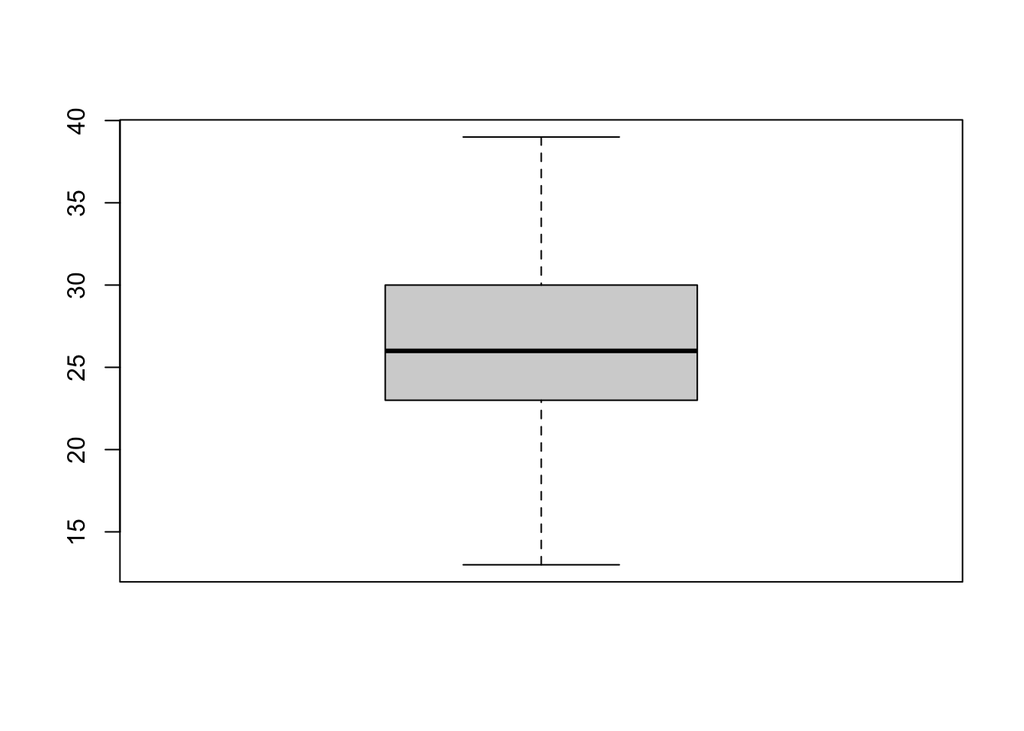

## centering based on this sample I standardized tanner stage, age at tanner assessment, and bmi within each sex

`r dem_plus_act_clin_netcorrcmep_cent <- dem_plus_act_clin_netcorrcmep %>% mutate( Sex = factor(Sex), COVID_AHC_ACT = factor(COVID_AHC_ACT), eff_perc_mean_z = scale(eff_perc_mean), sleep_time_hrs_mean_z = scale(sleep_time_hrs_mean), household_income_act_z = scale(Household_Income_ACT), sumsev_type_z = scale(sumsev_type), asq_total_act_z = scale(asq_total_act), cmep_total_act_z = scale(cmep_total_act), admn_lecn_act_z = scale(admn_lecn_act), admn_recn_act_z = scale(admn_recn_act), pdmn_lecn_act_z = scale(pdmn_lecn_act), pdmn_recn_act_z = scale(pdmn_recn_act), pDMN_Z_36R_z = scale(pDMN_Z_36R), aDMN_Z_36R_z = scale(aDMN_Z_36R), Noise_brainstem_Z_36R_z = scale(Noise_brainstem_Z_36R) ) %>% group_by(Sex) %>% mutate( tanner_average_for_act_z = scale(tanner_average_for_act), # standardize within each sex tanner_adrenal_act_z = scale(tanner_adrenal_act), tanner_gonadal_act_z = scale(tanner_gonadal_act), bmi_at_act_z = scale(BMI_ACT), tanner_age_for_act_z = scale(tanner_age_for_act) ) %>% ungroup()`

# test of potential covariates

`r # corr btwn cmep and interval between act and scan cor.test(dem_plus_act_clin_netcorrcmep_cent$cmep_total_act, dem_plus_act_clin_netcorrcmep_cent$interval_btwn_act_and_scan) # no corr, r = 0.06819312, p = 0.561`